# 20180410 meeting

Yosuke Fujii

20180410

Created at 2018-04-15 18:08:31.

# 1 Exercises

## 1.1 Exercise 1-1

正方行列の和を計算する関数は次のように作れる。 それにならって、行列の積(非正方行列を含む)を計算する関数を作成、それが正しいことを確かめよ。

The following function calculate sum of matrices. Make functions of production of (non-square) matrices in the similar way.

```r
my.matrix.sum <- function(x,y){
  dm <- dim(x)
  ret <- matrix(0,dm[1],dm[2])
  for(i in 1:dm[1]){
    for(j in 1:dm[2]){
      ret[i,j] <- x[i,j]+y[i,j]
    }
  }
  return(ret)
}

x <- matrix(c(2,3,4,5),2,2)
y <- matrix(c(4,5,6,7),2,2)
x + y
```

```
     [,1] [,2]
[1,]    6   10
[2,]    8   12
```

```r
my.matrix.sum(x,y)
```

```
     [,1] [,2]
[1,]    6   10
[2,]    8   12
```

```r
my.matrix.prod <- function(x, y){
  if(ncol(x) != nrow(y)){
    return("Dimension is not equal")
  } else {
    ret <- matrix(0, nrow(x), ncol(y))
    for(i in 1:nrow(x)){
      for(j in 1:ncol(y)){
        ret[i,j] <- sum(x[i,]*y[,j])
      }
    }
  return(ret)
  }
}

x <- rbind(x, x)
y <- t(x)
my.matrix.prod(x, y)
```

```
     [,1] [,2] [,3] [,4]
[1,]   20   26   20   26
[2,]   26   34   26   34
[3,]   20   26   20   26
[4,]   26   34   26   34
```

```r
x %*% y
```

```
     [,1] [,2] [,3] [,4]
[1,]   20   26   20   26
[2,]   26   34   26   34
[3,]   20   26   20   26
[4,]   26   34   26   34
```

## 1.2 Exercise 1-2

行列の冪$x^p$を計算する関数を作成せよ

Make a function of power of matrix.

```r
my.pow <- function(x, p=2){
  if(nrow(x) != ncol(x)){
    return("Not square matrix")
  } else {
    if(p > 1){
    ret <- x
    for(i in seq(p-1)){
      ret <- ret %*% x
    }
    return(ret)
    } else {
      return(x)
    }
  }
}
```

## 1.3 Exercise 1-3

行列の指数関数$e^{t \times X}$を計算する関数を作成せよ

Make a function of exponential of matix.

$e^A=\displaystyle\sum_{k=0}^\infty\frac{A^k}{k!}=I+\frac{A}{1!}+\frac{A^2}{2!}+\frac{A^3}{3!}+\cdots$

```r
mat.pow <- function(x, k=50){
  tmp <- mapply(function(z) my.pow(x, z)/factorial(z), 1:k, SIMPLIFY=FALSE)
  a <- abind::abind(tmp, along=3)
  ret <- matrix(c(sum(a[1,1,]), sum(a[1,2,]), sum(a[2,1,]), sum(a[2,2,])), 2, 2)
  return(ret)
}
```

## 1.4 Exercise 1-4

色々な$2 \times 2$ 行列を作り、それに基づく２変量連立微分方程式に関する解をプロットせよ。matplotと状態空間co-plotをせよ。カーブが多様であるように行列を選べ。

Make various $2 \times 2$ matrices and plot their answers of the system of differential equations of 2 variables. Plot them in two ways (matplot-way and co-plot-way in state space). Select matrices so that the curves of the variables are heterogeneous.

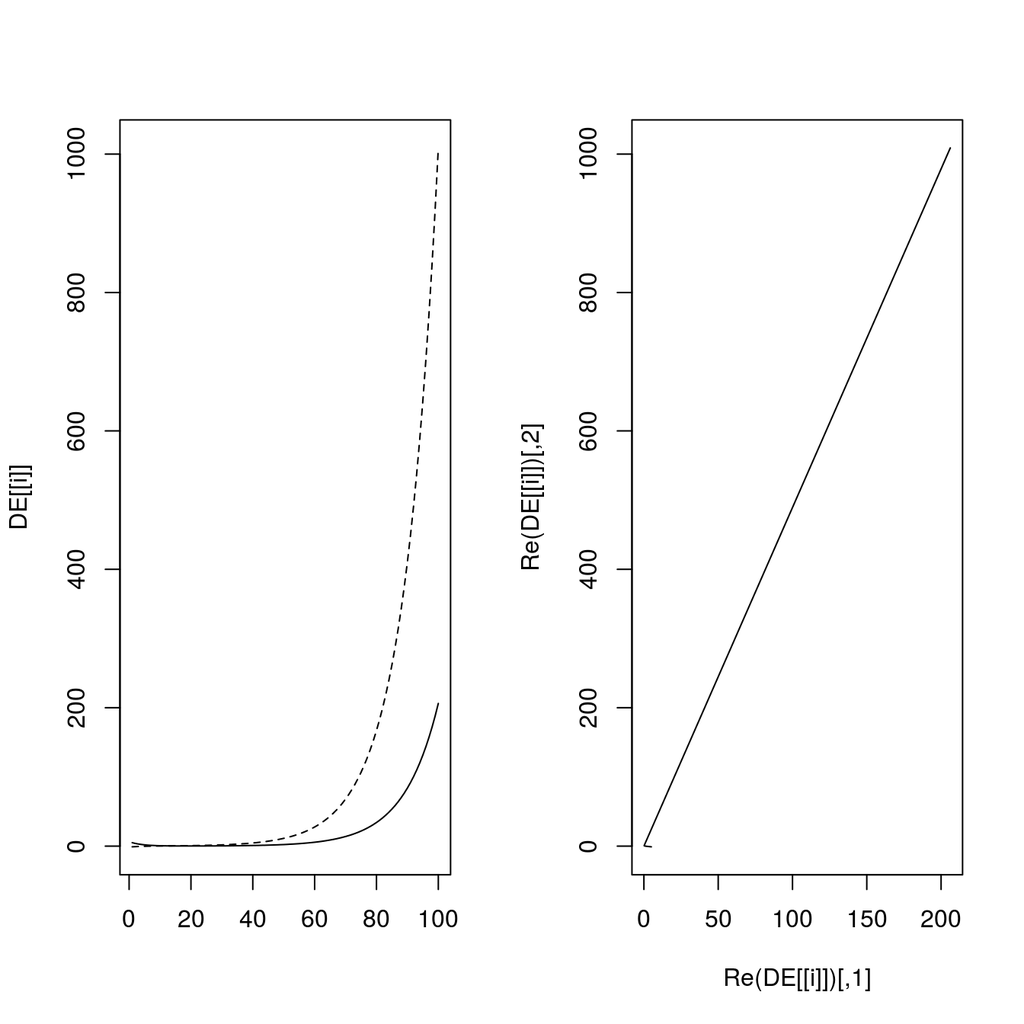

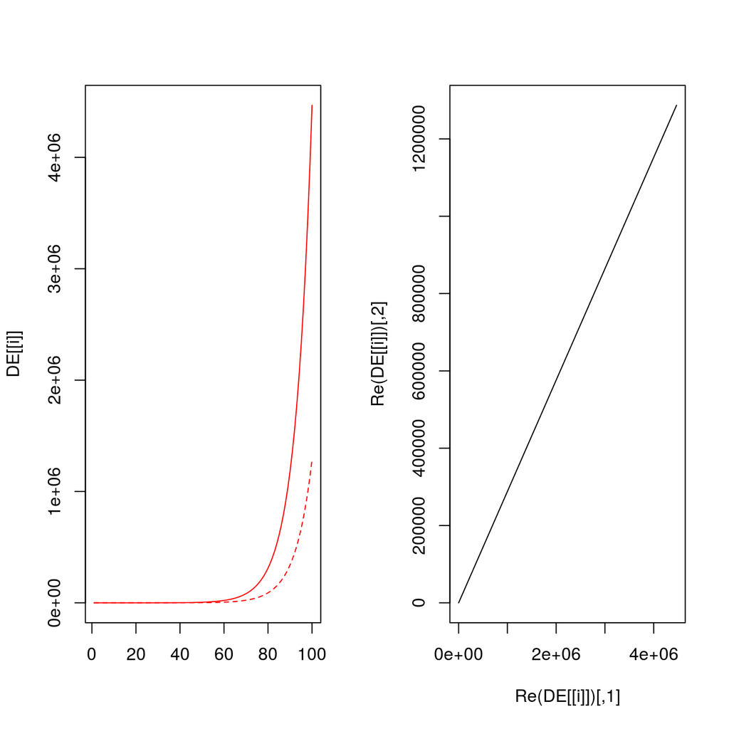

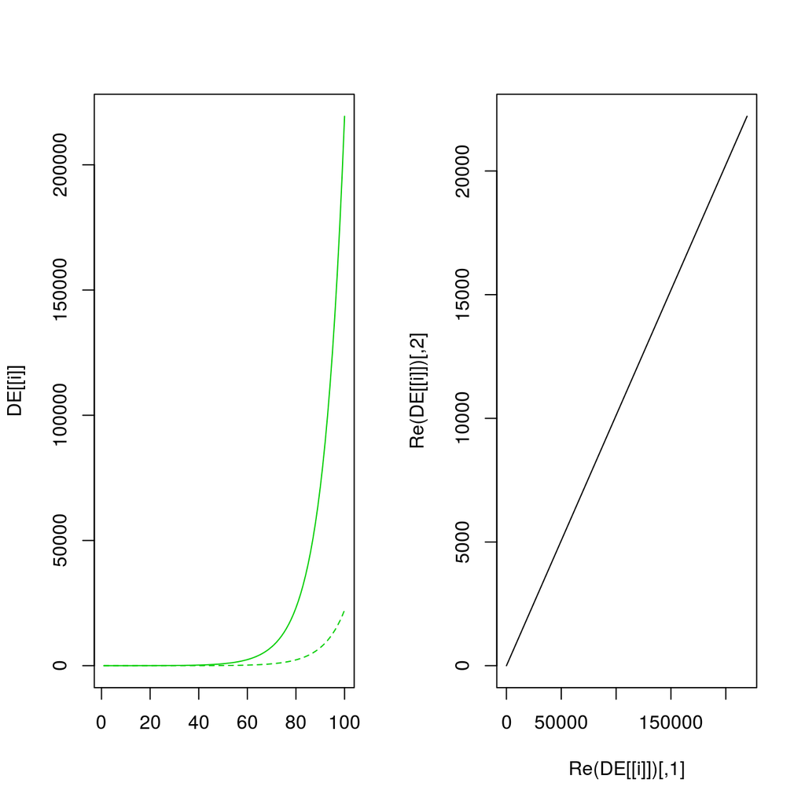

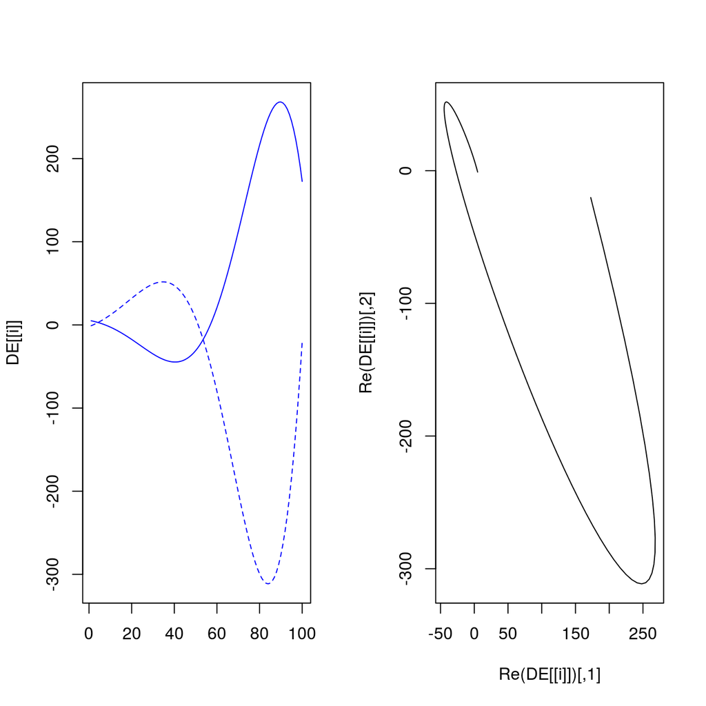

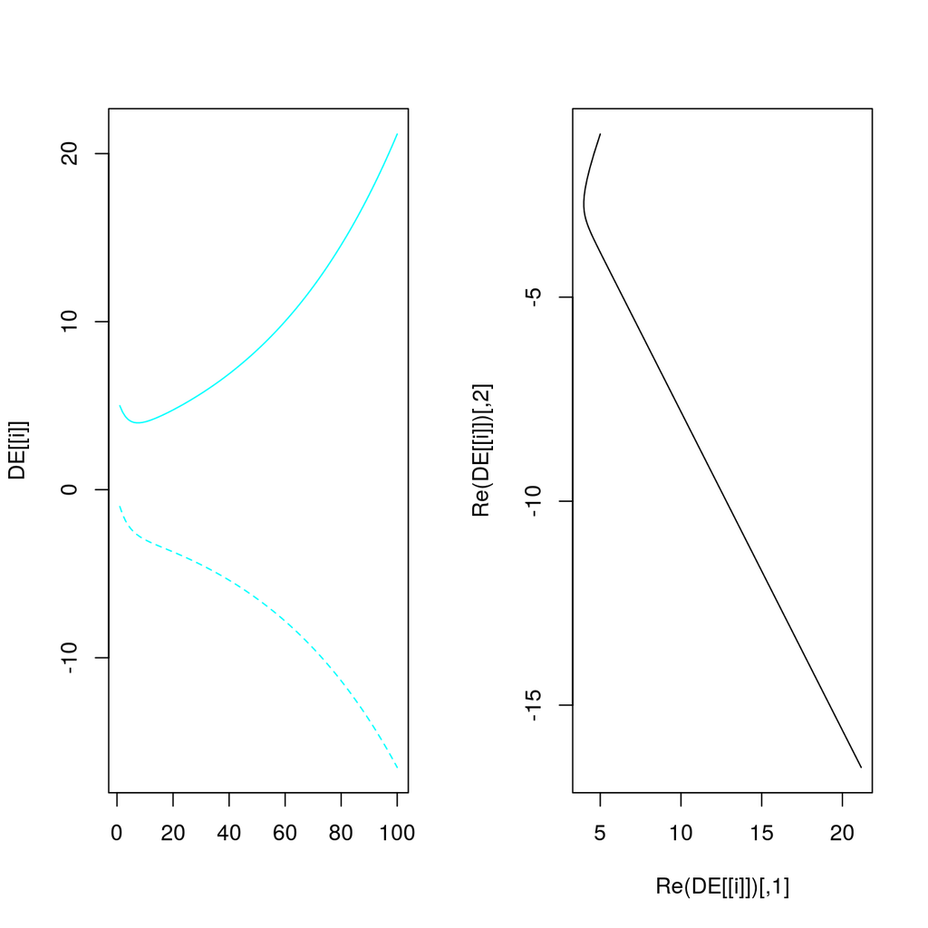

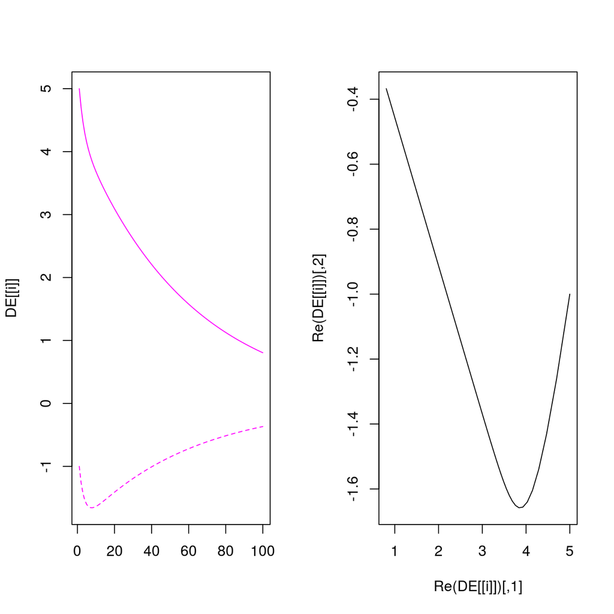

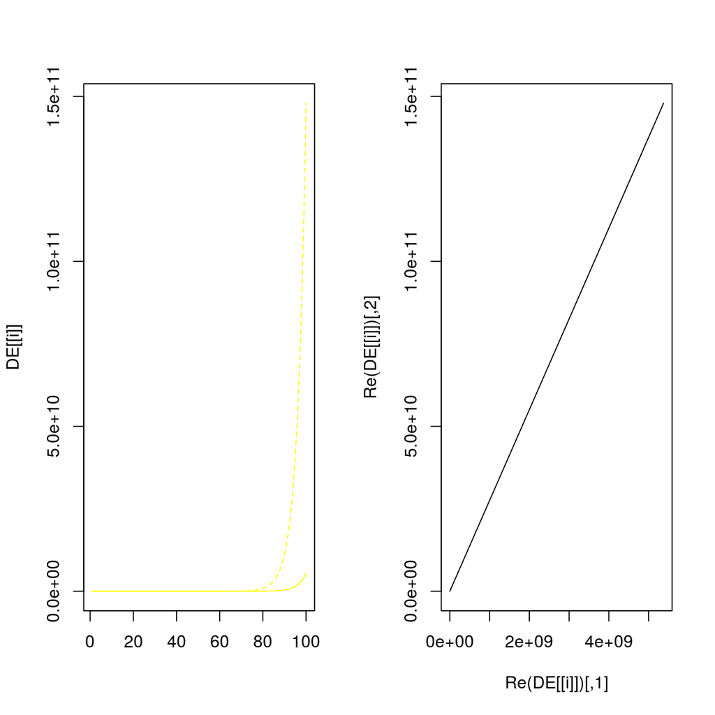

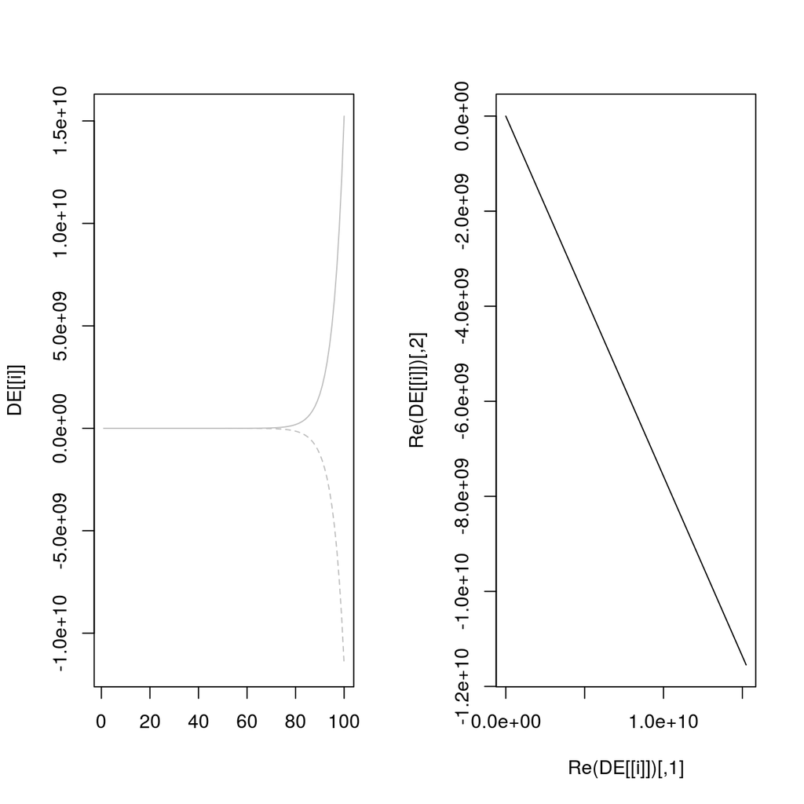

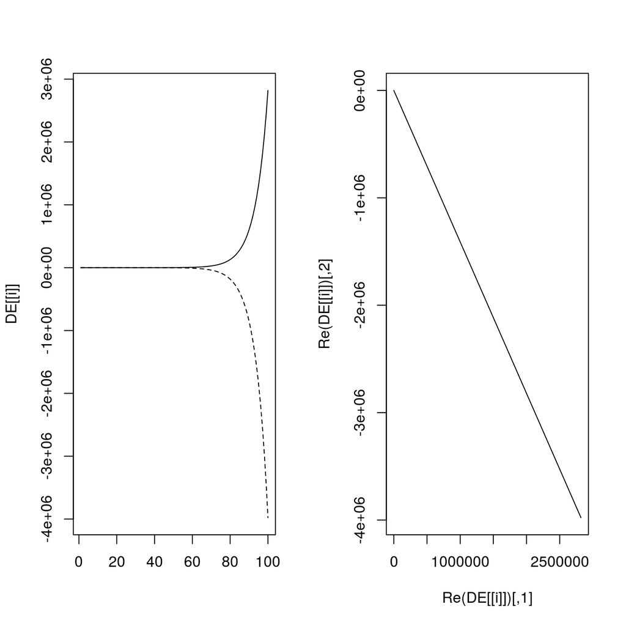

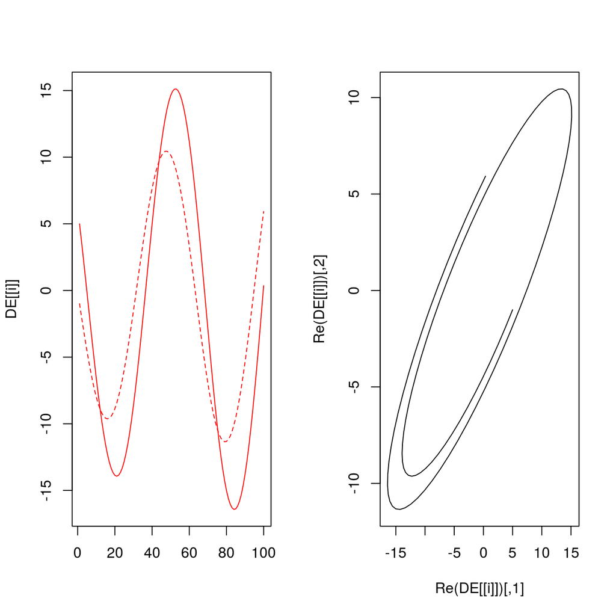

```r
# make various 2x2 matrices
iter <- 10

set.seed(1234)
M <- replicate(iter, matrix(runif(4, -1, 1), 2), simplify=FALSE)
diffeq <- function(mat,   x0=c(5,-1)){
  eigen.out <- eigen(mat)
  S <- diag(eigen.out[[1]])
  V <- eigen.out[[2]]
  t <- seq(from=0,to=30,length=100)
  xs <- matrix(0,length(t), nrow(mat))
  for(i in 1:length(t)){
    etA <- V %*% diag(exp(t[i]*diag(S))) %*% solve(V)
    xs[i,] <- etA %*% x0
  }
  return(xs)
}

DE <- mapply(diffeq, M, SIMPLIFY=FALSE)

for(i in 1:10){
  par(mfrow=c(1, 2))
  matplot(DE[[i]], col=i, lty=1:2, type="l")
  plot(Re(DE[[i]]), type="l")
}
```

## 1.5 Exercise 1-5

$3 \times 3$ 行列による3変量の場合を同様に行え。matplot-wayと3次元状態空間プロットを行え。 さまざまなカーブを描くように、行列を選べ。

Make various $3 \times 3$ matrices for three variables’ system of differential equations.

plot them in two ways (matplot-way and 3D-plot-way in state space).

Select matrices so that the curves or the variables are heterogeneous.

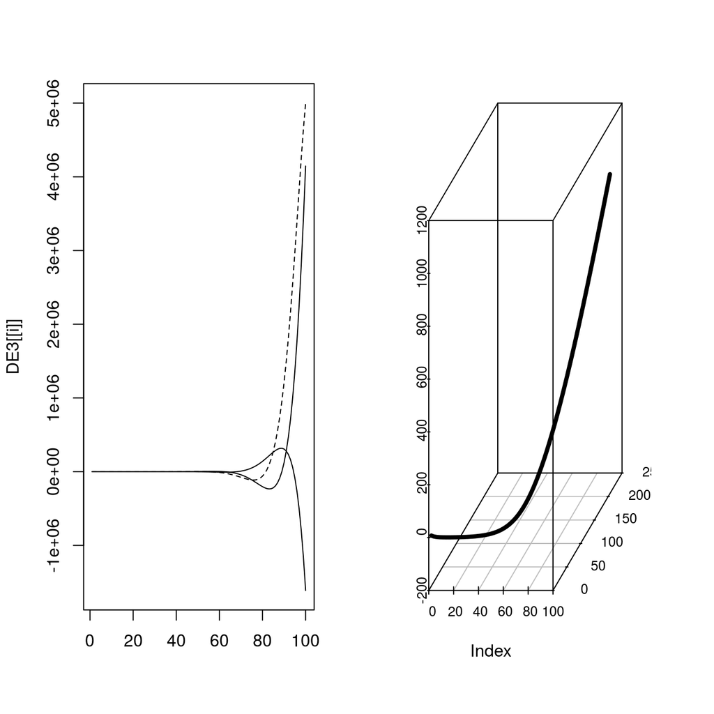

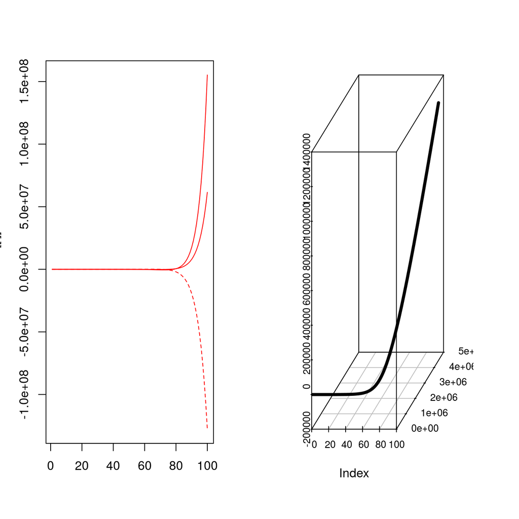

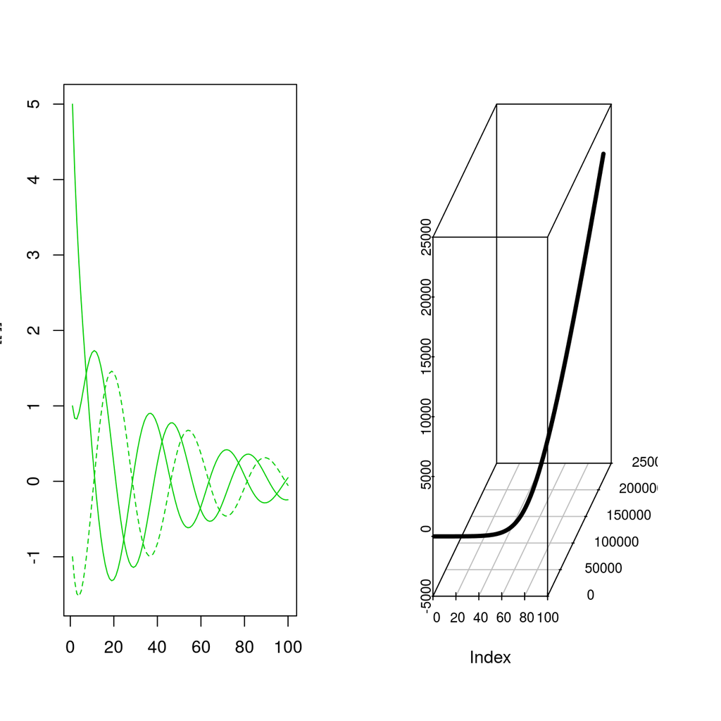

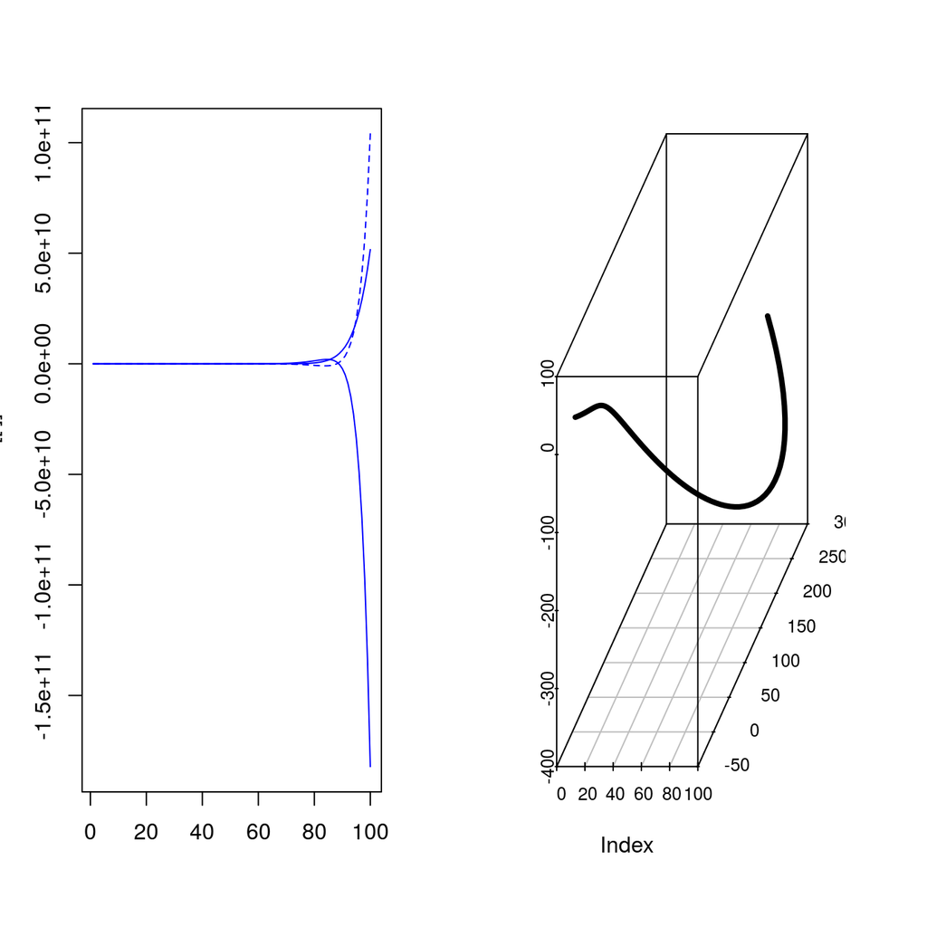

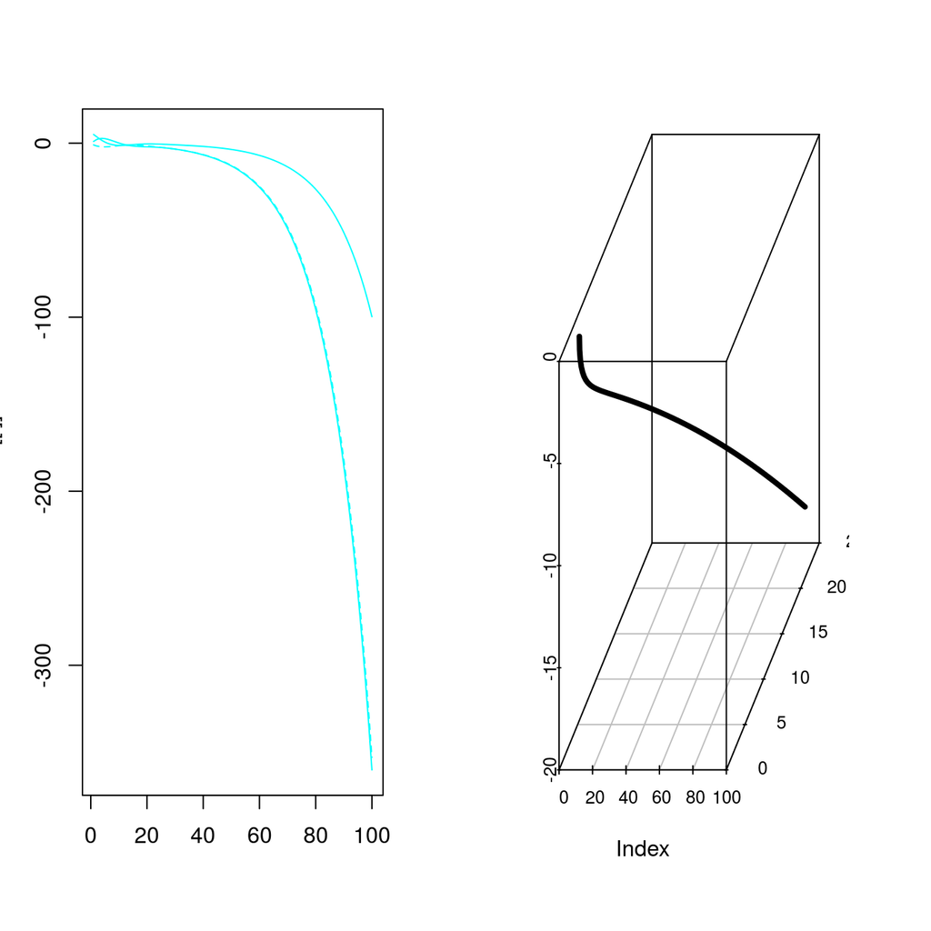

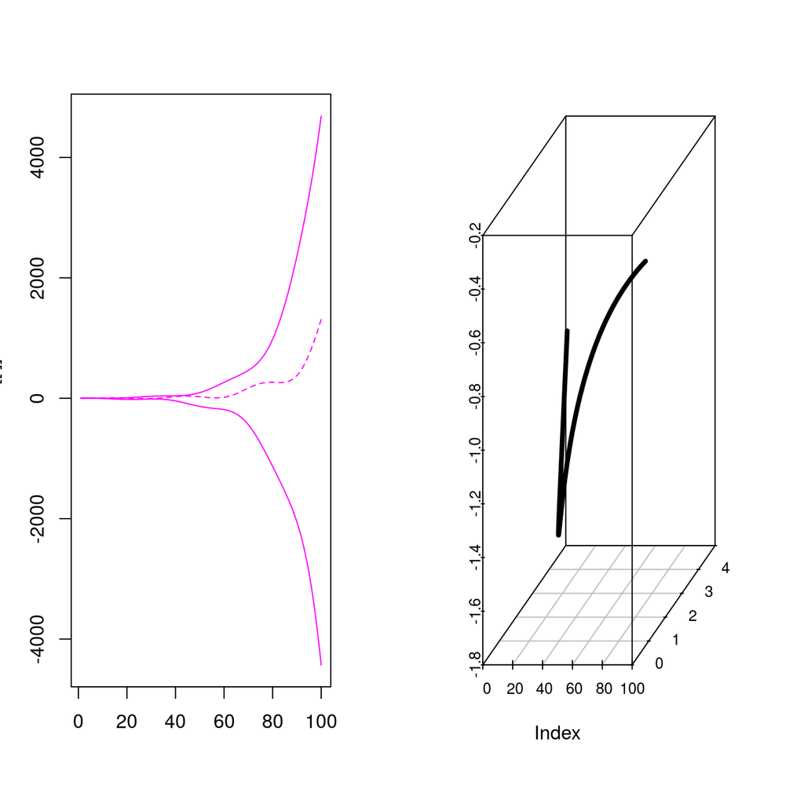

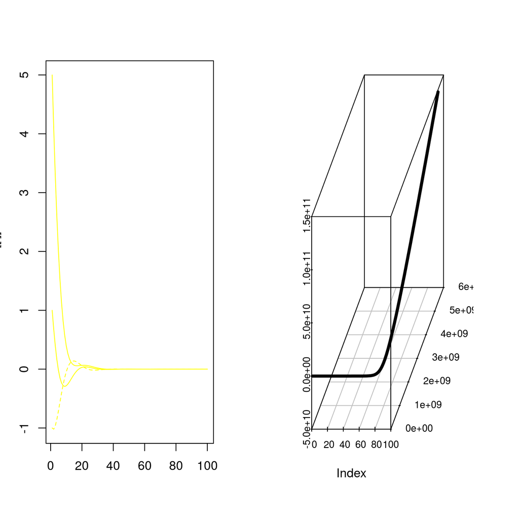

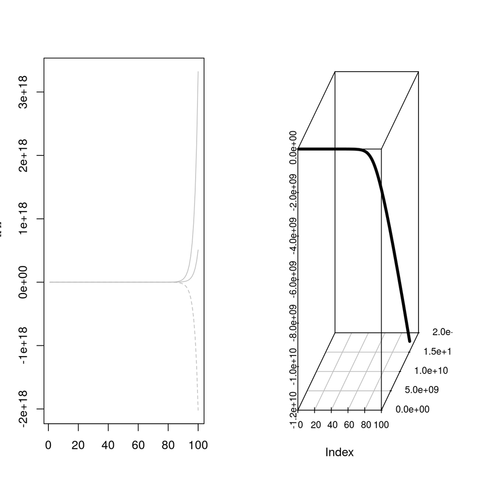

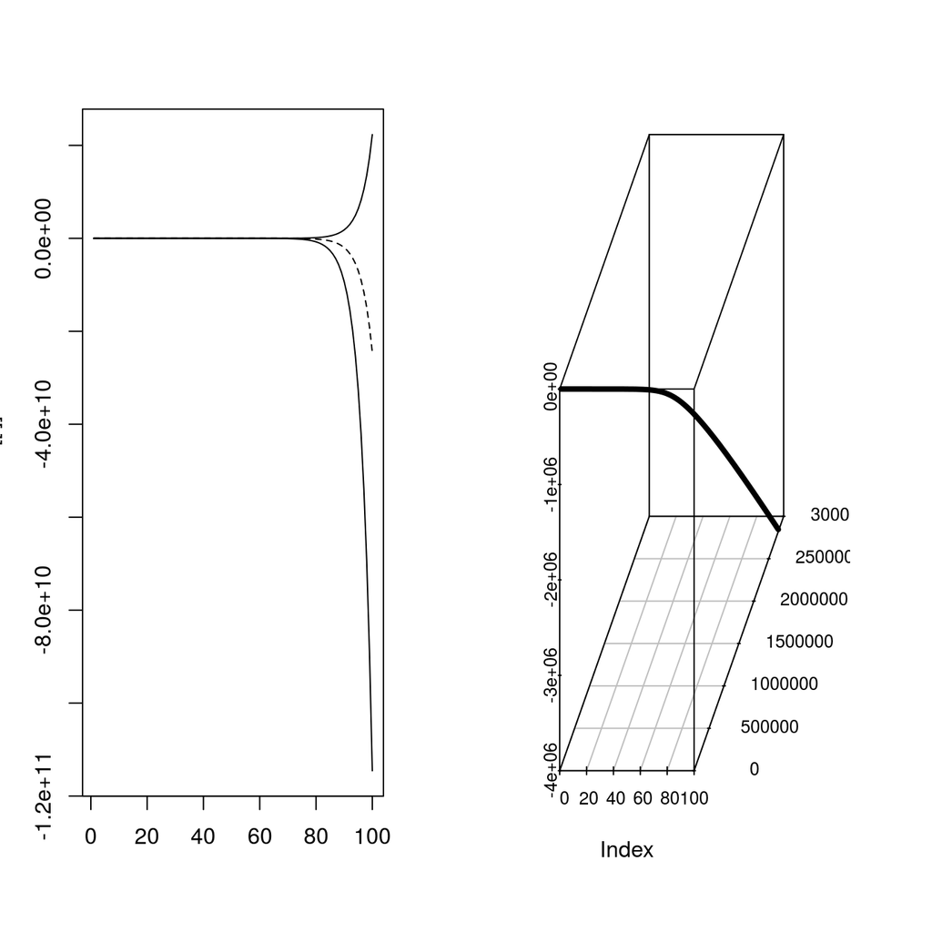

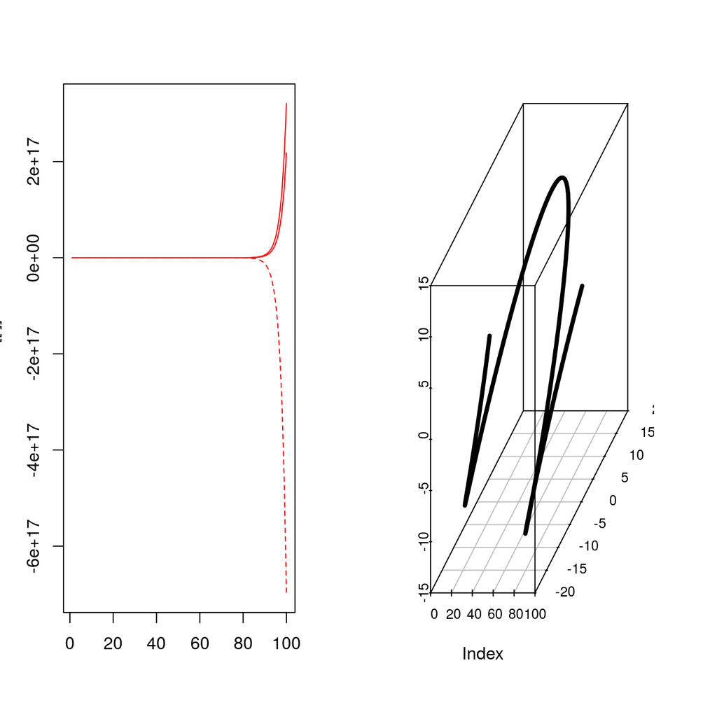

```r
set.seed(1234)
M <- replicate(iter, matrix(runif(9, -1, 1), 3), simplify=FALSE)

x0 <- c(5, -1, 1)
DE3 <- mapply(diffeq, M, list(x0), SIMPLIFY=FALSE)

for(i in 1:10){
  par(mfrow=c(1, 2))
  matplot(DE3[[i]], col=i, lty=1:2, type="l")
  scatterplot3d::scatterplot3d(Re(DE[[i]]), type="l", lwd=4)
}
```

$f(x)=\frac{1}{\sqrt{2\pi\sigma^2}}\exp{(-\frac{(x-\mu)^2}{2\sigma^2})}$

$f(x)=\frac{1}{(\sqrt{2\pi})^n\sqrt{|\Sigma|}}\exp{(-\frac{1}{2}(x-\mu)^T\Sigma^{-1}(x-\mu))}$

単変量ならば$\Sigma^{-1}=\frac{1}{\sigma^2}$ とすると、2式は同じになる。

# 2 +, -, x and /

## 2.1 Calculation of real numbers 実数の計算

```r
x <- 3
y <- -5
x+y
```

```
[1] -2
```

```r
x-y
```

```
[1] 8
```

```r
x*y
```

```
[1] -15
```

```r
x/y
```

```
[1] -0.6
```

### 2.1.1 Important numbers 大事な値

```r
zero <- 0
one <- 1
x
```

```
[1] 3
```

```r
x + zero
```

```
[1] 3
```

```r
x * zero
```

```
[1] 0
```

```r
x * one
```

```
[1] 3
```

```r
x.inverse <- 1/x
x * x.inverse
```

```
[1] 1
```

```r
x/y
```

```
[1] -0.6
```

```r
y.inverse <- 1/y
x * y.inverse
```

```
[1] -0.6
```

## 2.2 Square matrices 正方行列

### 2.2.1 $2 \times 2$ matrices

```r
X <- matrix(c(1,2,3,4),2,2)
X
```

```
     [,1] [,2]
[1,]    1    3
[2,]    2    4
```

```r
Y <- matrix(c(4,5,6,7),2,2)
Y
```

```
     [,1] [,2]
[1,]    4    6
[2,]    5    7
```

```r
X+Y
```

```
     [,1] [,2]
[1,]    5    9
[2,]    7   11
```

```r
X-Y
```

```
     [,1] [,2]
[1,]   -3   -3
[2,]   -3   -3
```

```r
X %*% Y
```

```
     [,1] [,2]
[1,]   19   27
[2,]   28   40
```

```r
Y %*% X
```

```
     [,1] [,2]
[1,]   16   36
[2,]   19   43
```

Calculate yourself without computers. 計算機を使わずに計算すること。

#### 2.2.1.1 Important matrices

```r
ONE <- matrix(c(1,0,0,1),2,2)
ONE
```

```
     [,1] [,2]
[1,]    1    0
[2,]    0    1
```

```r
ZERO <- matrix(0,2,2)
ZERO
```

```
     [,1] [,2]
[1,]    0    0
[2,]    0    0
```

```r
X.inverse <- solve(X)
X
```

```
     [,1] [,2]
[1,]    1    3
[2,]    2    4
```

```r
X.inverse
```

```
     [,1] [,2]
[1,]   -2  1.5
[2,]    1 -0.5
```

```r
X %*% X.inverse
```

```
     [,1] [,2]
[1,]    1    0
[2,]    0    1
```

```r
X.inverse %*% X
```

```
     [,1] [,2]
[1,]    1    0
[2,]    0    1
```

```r
# x/y
Y.inverse <- solve(Y)
X %*% Y.inverse
```

```
     [,1] [,2]
[1,]    4   -3
[2,]    3   -2
```

```r
Y.inverse %*% X
```

```
     [,1] [,2]
[1,]  2.5  1.5
[2,] -1.5 -0.5
```

### 2.2.2 $n \times n$ matrices $n \times n$ 行列

```r
n <- sample(3:5,1)
X <- matrix(sample((-20):20,n^2,replace=TRUE),n,n)
Y <- matrix(sample((-20):20,n^2,replace=TRUE),n,n)
X
```

```
     [,1] [,2] [,3]
[1,]   16  -16  -19
[2,]  -15    0   -8
[3,]  -15   -8   10
```

```r
X + Y
```

```
     [,1] [,2] [,3]
[1,]   -3  -28  -33
[2,]  -12  -15  -23
[3,]  -24  -15    7
```

```r
X - Y
```

```
     [,1] [,2] [,3]
[1,]   35   -4   -5
[2,]  -18   15    7
[3,]   -6   -1   13
```

```r
X %*% Y
```

```
     [,1] [,2] [,3]
[1,] -181  181   73
[2,]  357  236  234
[3,]  171  230  300
```

```r
X %*% solve(X)
```

```
              [,1]          [,2]         [,3]
[1,]  1.000000e+00 -1.110223e-16 0.000000e+00
[2,] -5.551115e-17  1.000000e+00 5.551115e-17
[3,]  0.000000e+00  1.110223e-16 1.000000e+00
```

```r
solve(X) %*% X
```

```
              [,1]          [,2]          [,3]
[1,]  1.000000e+00 -5.551115e-17 -5.551115e-17
[2,] -1.110223e-16  1.000000e+00  0.000000e+00
[3,]  5.551115e-17  0.000000e+00  1.000000e+00
```

```r
X %*% solve(Y)
```

```
           [,1]       [,2]      [,3]
[1,] -0.1879699  1.6109023 -0.843985
[2,]  1.3458647 -0.4573935 -1.327068
[3,] -1.1353383 -0.3934837  3.932331
```

```r
solve(Y) %*% X
```

```
           [,1]        [,2]       [,3]
[1,] -0.9022556  0.75187970  0.2155388
[2,]  5.1654135  0.19548872 -3.4172932
[3,] -4.3458647 -0.04511278  3.9937343
```

#### 2.2.2.1 Important matrices

```r
ONE <- diag(rep(1,n))
ONE
```

```
     [,1] [,2] [,3]
[1,]    1    0    0
[2,]    0    1    0
[3,]    0    0    1
```

```r
ZERO <- matrix(0,n,n)
ZERO
```

```
     [,1] [,2] [,3]
[1,]    0    0    0
[2,]    0    0    0
[3,]    0    0    0
```

```r
X.inverse <- solve(X)
X
```

```
     [,1] [,2] [,3]
[1,]   16  -16  -19
[2,]  -15    0   -8
[3,]  -15   -8   10
```

```r
X.inverse
```

```
             [,1]        [,2]        [,3]
[1,]  0.008394544 -0.04092340 -0.01678909
[2,] -0.035414481  0.01639559 -0.05417104
[3,] -0.015739769 -0.04826863  0.03147954
```

# 3 Power and exponential

## 3.1 Power to integer

```r
x <- 3
p <- 2
x^p
```

```
[1] 9
```

```r
x * x
```

```
[1] 9
```

```r
p <- 3
x^3
```

```
[1] 27
```

```r
x * x * x
```

```
[1] 27
```

```r
X <- matrix(c(1,2,3,4),2,2)
p <- 2
X %*% X
```

```
     [,1] [,2]
[1,]    7   15
[2,]   10   22
```

```r
p <- 3
X %*% X %*% X
```

```
     [,1] [,2]
[1,]   37   81
[2,]   54  118
```

## 3.2 Power to non-integer

```r
x <- 2
p <- 2
x. <- x^p
x.
```

```
[1] 4
```

```r
p.inverse <- 1/p
p.inverse
```

```
[1] 0.5
```

```r
x.^p.inverse
```

```
[1] 2
```

## 3.3 Power of diagonal matrix

```r
X <- matrix(c(2,0,0,3),2,2) # Diagonal matrix
X
```

```
     [,1] [,2]
[1,]    2    0
[2,]    0    3
```

```r
diag(c(2,3))
```

```
     [,1] [,2]
[1,]    2    0
[2,]    0    3
```

```r
X %*% X
```

```
     [,1] [,2]
[1,]    4    0
[2,]    0    9
```

```r
p <- 2
p.inverse <- 1/p
diag.X <- diag(X)
diag.X
```

```
[1] 2 3
```

```r
diag(diag.X^p)
```

```
     [,1] [,2]
[1,]    4    0
[2,]    0    9
```

```r
diag(diag.X^p.inverse)
```

```
         [,1]     [,2]
[1,] 1.414214 0.000000
[2,] 0.000000 1.732051
```

## 3.4 Decomposition of matrix 行列の分解

Eigen value decomposition 固有値分解

$X = V S V^{-1}$ $X^2 = (V S V^{-1}) (V S V^{-1}) = (VS)(V^{-1}V)(SV^{-1})=V(S^2)V^{-1}$ $X^p = V(S^p)V^{-1}$

```r
X <- matrix(c(2,3,4,5),2,2)
eigen.out <- eigen(X)
eigen.out
```

```
eigen() decomposition
$values
[1]  7.2749172 -0.2749172

$vectors
           [,1]       [,2]
[1,] -0.6042272 -0.8692521
[2,] -0.7968121  0.4943691
```

```r
V <- eigen.out[[2]]
S <- diag(eigen.out[[1]])
V %*% S %*% solve(V)
```

```
     [,1] [,2]
[1,]    2    4
[2,]    3    5
```

```r
X %*% X
```

```
     [,1] [,2]
[1,]   16   28
[2,]   21   37
```

```r
V %*% diag(eigen.out[[1]]^2) %*% solve(V)
```

```
     [,1] [,2]
[1,]   16   28
[2,]   21   37
```

```r
X. <- V %*% diag(eigen.out[[1]]^(1/2)) %*% solve(V)
X.
```

```
     [,1] [,2]
[1,]  NaN  NaN
[2,]  NaN  NaN
```

```r
s <- complex(real=eigen.out[[1]],imaginary=0)
s^(1/2)
```

```
[1] 2.697205+0.0000000i 0.000000+0.5243255i
```

```r
X.. <- V %*% diag(s^(1/2)) %*% solve(V)
X..
```

```
                     [,1]               [,2]
[1,] 0.8127223+0.3663357i 1.429014-0.277794i
[2,] 1.0717608-0.2083458i 1.884483+0.157990i
```

```r
X.. %*% X..
```

```
     [,1] [,2]
[1,] 2+0i 4-0i
[2,] 3+0i 5-0i
```

## 3.5 Matrix exponential

指数関数の性質 $\frac{d}{dx} e^x= e^x$ $e^0=1$

指数関数の定義式

$e^x = \sum_{k=0}^{\infty} \frac{1}{k!}x^k$

$e^X = \sum_{k=0}^{\infty} \frac{1}{k!}X^k$

$e^{VSV^{-1}} = \sum_{k=0}^{\infty} \frac{1}{k!}VS^kV^{-1} = V(\sum_{k=0}^{\infty} \frac{1}{k!} S^k) V^{-1}$

対角成分ごとに$e^x$を計算できる

```r
X <- matrix(c(2,3,4,5),2,2)
eigen.out <- eigen(X)
s <- eigen.out[[1]]
V <- eigen.out[[2]]
s
```

```
[1]  7.2749172 -0.2749172
```

```r
V
```

```
           [,1]       [,2]
[1,] -0.6042272 -0.8692521
[2,] -0.7968121  0.4943691
```

```r
V %*% diag(exp(s))%*% solve(V)
```

```
         [,1]      [,2]
[1,] 435.5261  764.4523
[2,] 573.3392 1008.8653
```

# 4 非正方行列の積 Multiplication of non-square matrices

```r
n <- 4
m <- 3
k <- 2

M1 <- matrix(1:(n*m),n,m)
M1
```

```
     [,1] [,2] [,3]
[1,]    1    5    9
[2,]    2    6   10
[3,]    3    7   11
[4,]    4    8   12
```

```r
dim(M1)
```

```
[1] 4 3
```

```r
M2 <- matrix(1:(k*n),k,n)
M2
```

```
     [,1] [,2] [,3] [,4]
[1,]    1    3    5    7
[2,]    2    4    6    8
```

```r
dim(M2)
```

```
[1] 2 4
```

```r
M21 <- M2 %*% M1
M21
```

```
     [,1] [,2] [,3]
[1,]   50  114  178
[2,]   60  140  220
```

```r
dim(M21)
```

```
[1] 2 3
```

```r
M3 <- matrix(1:(m*k),m,k)
M13 <- M1 %*% M3
M13
```

```
     [,1] [,2]
[1,]   38   83
[2,]   44   98
[3,]   50  113
[4,]   56  128
```

```r
dim(M13)
```

```
[1] 4 2
```

## 4.1 ベクトルの内積 Inner product of vectors

A vector with n elements can be considered $n\times 1$ matrix or $1 \times n$ matrix.

要素数 n のベクトルは$n\times 1$行列、$1 \times n$行列とみなせる。

```r
n <- 3
v1 <- c(3,5,6)
v2 <- c(1,2,4)
V1 <- matrix(v1,nrow=n)
V1
```

```
     [,1]
[1,]    3
[2,]    5
[3,]    6
```

```r
V2 <- matrix(v2,nrow=1)
V2
```

```
     [,1] [,2] [,3]
[1,]    1    2    4
```

$n \times 1$ matrix can be multiplied by $1 \times n$ matrix from its left. The product is $1 \times 1$ matrix, or a scaler value.

$n \times 1$ 行列には、その左側から$1 \times n$行列を掛けることができる。その積は$1 \times 1$ 行列、もしくは、スカラー値である。

```r
V2 %*% V1
```

```
     [,1]
[1,]   37
```

The following returns the same value. 次のような計算と同じである。

```r
sum(v1*v2)
```

```
[1] 37
```

# 5 Differential equation 微分方程式

## 5.1 Single differential equation １つの微分方程式

$\frac{d x(t)}{dt} = a x$

解 $x(t) = b \times e^at$

## 5.2 System of differential equation 連立微分方程式

$\begin{pmatrix} \frac{dx_1}{dt} \\ \frac{dx_2}{dt} \end{pmatrix} = \begin{pmatrix} a & b \\ c & d \end{pmatrix} \begin{pmatrix} x_1\\ x_2 \end{pmatrix}$

The solution of this system is known as, この連立微分方程式の解は以下であると知られている。

```r
A <- matrix(c(0.5,1,-1,-0.3),2,2)
A
```

```
     [,1] [,2]
[1,]  0.5 -1.0
[2,]  1.0 -0.3
```

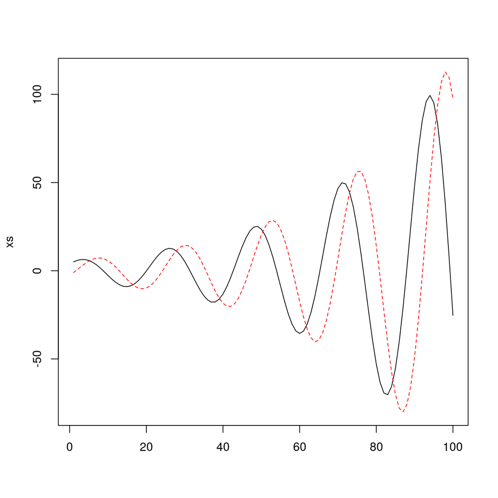

```r
eigen.out <- eigen(A)
S <- diag(eigen.out[[1]])
V <- eigen.out[[2]]

t <- seq(from=0,to=30,length=100)
x0 <- c(5,-1)
xs <- matrix(0,length(t),2)
for(i in 1:length(t)){
  etA <- V %*% diag(exp(t[i]*diag(S))) %*% solve(V)
  xs[i,] <- etA %*% x0
}
matplot(xs,type="l")
```

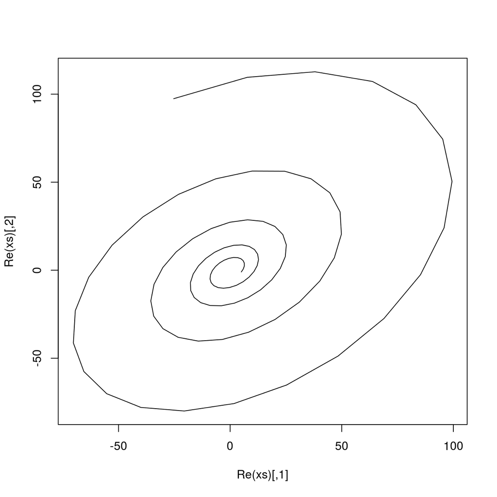

```r
plot(Re(xs),type="l") # state space plot
```